# IODS course project

Hypothesis: - We can infer that alcohol use will be negatively related with the family support experienced, as a more supportive environment should provide a layer of protection against alcohol abuse. - On the other end, I would expect for absences and failure to be positively influencing the use of alcohol, with perhaps absences having slightly higher weight on this relationship. - For sex, it should be reasonable to admit a higher prevalence of high alcohol use from male students compared to their female counterparts.

```
## # A tibble: 5 × 2
##   famrel count
##    <int> <int>
## 1      1     8
## 2      2    18
## 3      3    64
## 4      4   180
## 5      5   100
```

```
## # A tibble: 26 × 2
##    absences count
##       <int> <int>
##  1        0    63
##  2        1    50
##  3        2    56
##  4        3    38
##  5        4    35
##  6        5    22
##  7        6    21
##  8        7    12
##  9        8    20
## 10        9    11
## # … with 16 more rows
```

```
## # A tibble: 4 × 2
##   failures count
##      <int> <int>
## 1        0   325
## 2        1    24
## 3        2    17
## 4        3     4
```

```
## # A tibble: 2 × 2
##   sex   count
##   <chr> <int>
## 1 F       195
## 2 M       175
```

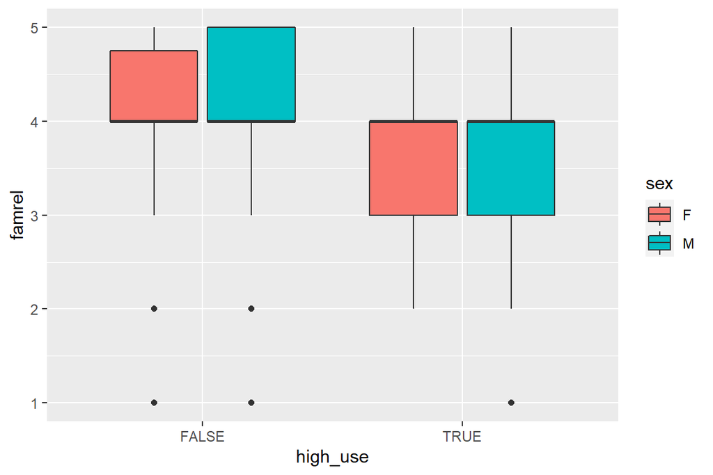

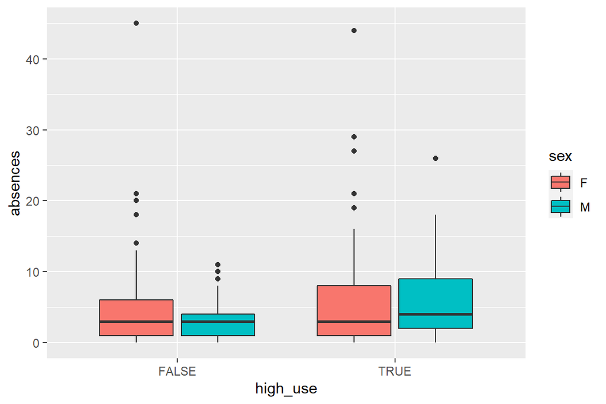

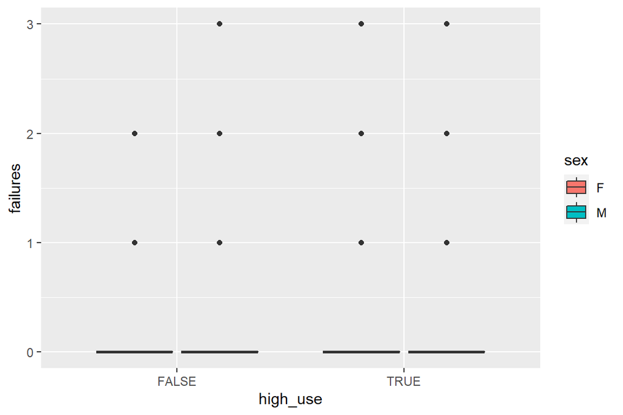

[figure not shown]

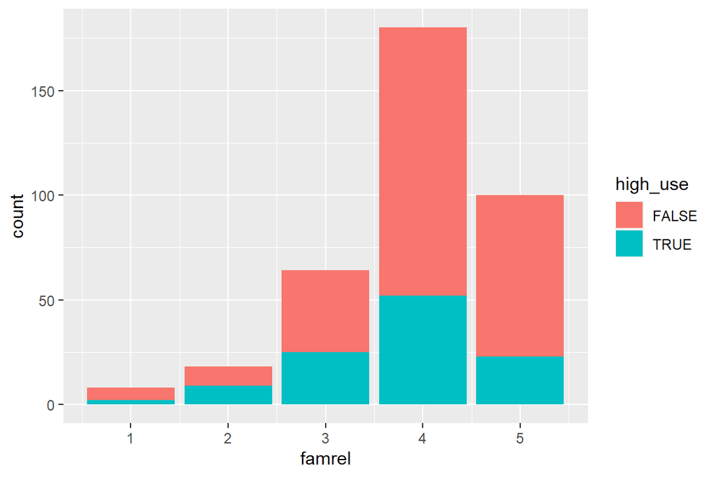

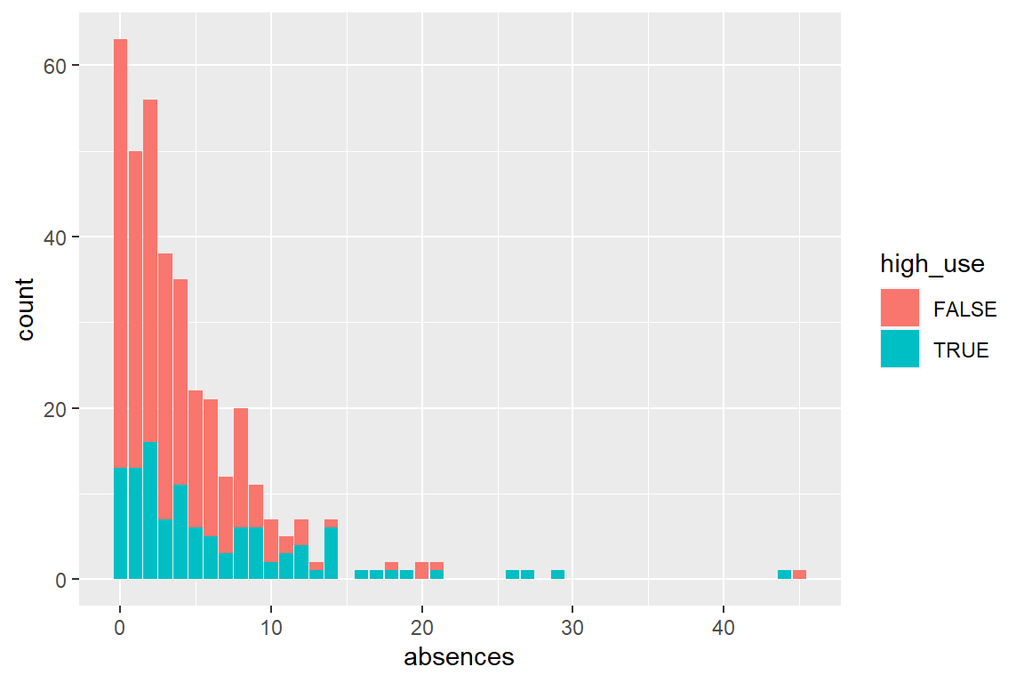

By looking at the charts we can deduce that our hypothesis are at least on the right track, as the data shows a higher prevalence for high alcohol use as family relation quality reduces; and also as failures and absences increase. Lastly, we also see promising data regarding our gender hypothesis.

```
##
## Call:
## glm(formula = high_use ~ famrel + failures + absences + sex,
##     family = "binomial", data = alc)
##
## Deviance Residuals:
##     Min       1Q   Median       3Q      Max
## -2.0786  -0.8216  -0.5746   0.9760   2.1820
##
## Coefficients:
##             Estimate Std. Error z value Pr(>|z|)
## (Intercept) -0.79406    0.54281  -1.463  0.14350
## famrel      -0.29791    0.13044  -2.284  0.02238 *
## failures     0.57328    0.20531   2.792  0.00523 **
## absences     0.08941    0.02274   3.932 8.43e-05 ***
## sexM         1.04800    0.25091   4.177 2.96e-05 ***
## ---
## Signif. codes:  0 '***' 0.001 '**' 0.01 '*' 0.05 '.' 0.1 ' ' 1
##
## (Dispersion parameter for binomial family taken to be 1)
##
##     Null deviance: 452.04  on 369  degrees of freedom
## Residual deviance: 401.77  on 365  degrees of freedom
## AIC: 411.77
##
## Number of Fisher Scoring iterations: 4
```

```
## (Intercept)      famrel    failures    absences        sexM
## -0.79406437 -0.29791173  0.57327802  0.08940969  1.04800182
```

Upon looking at the coefficients of the model, I can reject the null hypothesis, as all the selected variables have a statistically significant impact on high alcohol use.

More specifically, we observe how the increments in Family Relation is negatively linked to high use of alcohol, as we expected (z = -2.28, p < 0.05).

Regarding Failures, the coefficient shows a direct positive relation with alcohol abuse (z = 2.79, p < 0.05)

Absences also reflect a direct positive link to our target variable, with a specifically significant relation (z = 3.93, p < 0.001)

Lastly, the variable with the mopst impact in our model was gender, as being male significantly increased the relationship with high alcohol use (z = 4.18, z < 0.001)

The next step is transforming these coefficients into Odds Ratios, and providing their respectives confident intervals (CI)

```
##                 2.5 %    97.5 %
## (Intercept) 0.1532656 1.2982302
## famrel      0.5735490 0.9583804
## failures    1.1936470 2.6881229
## absences    1.0480739 1.1462668
## sexM        1.7556470 4.7047758
```

```
##                    OR     2.5 %    97.5 %
## (Intercept) 0.4520039 0.1532656 1.2982302
## famrel      0.7423669 0.5735490 0.9583804
## failures    1.7740730 1.1936470 2.6881229
## absences    1.0935286 1.0480739 1.1462668
## sexM        2.8519467 1.7556470 4.7047758
```

The odds ratio provide another source of confirmation of our initial hypothesis, as for example:

- Famrel OR: 0.74; meaning that the probability of falling into High Use decreases as the quality of the family relations increase.
- Failures OR: 1.77; this showcases that the probability of High Alcohol use increases directly as Failures increase.
- Absences OR: 1.09; in a similar way to failures, absences also influence the probability of High Alcohol Use directly, although at a slower rate.
- SexM OR: 2.85; unsurprisingly, gender also had the most significant impact on the odds of developing a High Alcohol Use, compared to the rest of variables selected.

```
##     failures famrel absences sex high_use probability prediction
## 361        0      4        3   M    FALSE   0.3386132      FALSE
## 362        1      4        0   M    FALSE   0.4098873      FALSE
## 363        1      5        7   M     TRUE   0.4908822      FALSE
## 364        0      5        1   F    FALSE   0.1002713      FALSE
## 365        0      4        6   F    FALSE   0.1901165      FALSE
## 366        1      5        2   F    FALSE   0.1777706      FALSE
## 367        0      4        2   F    FALSE   0.1410142      FALSE
## 368        0      1        3   F    FALSE   0.3049689      FALSE
## 369        0      2        4   M     TRUE   0.5039381       TRUE
## 370        0      4        2   M     TRUE   0.3188873      FALSE
```

```
##         prediction
## high_use FALSE TRUE
##    FALSE   244   15
##    TRUE     77   34
```

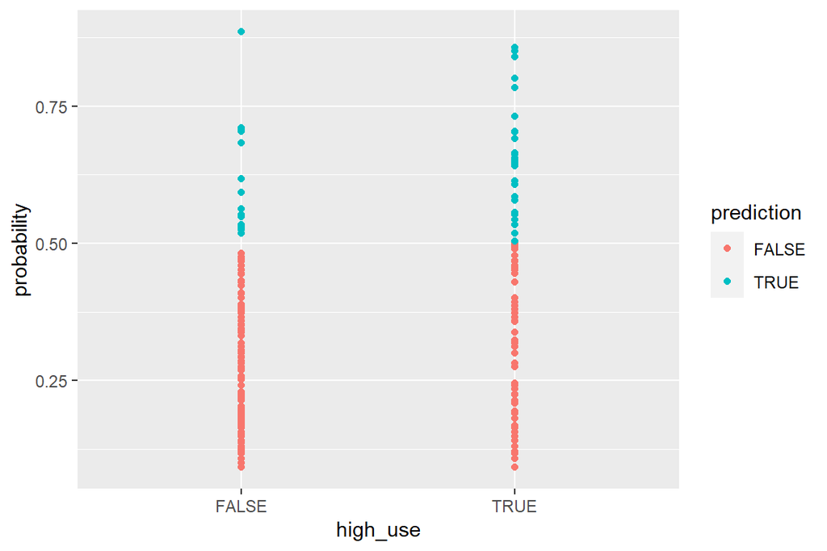

```
##         prediction
## high_use      FALSE       TRUE        Sum
##    FALSE 0.65945946 0.04054054 0.70000000
##    TRUE  0.20810811 0.09189189 0.30000000
##    Sum   0.86756757 0.13243243 1.00000000
```

Overall, this chapter has resulted slightly more intuitive and easy to follow for me, and the practical applications of it are much more clear for me now. The last bonus exercises might have been still off reach but I am looking forward to learn how to incorporate it during the next lesson!

(more chapters to be added similarly as we proceed with the course!)